# main

```python
import numpy as np
import xgboost as xgb
import pandas as pd
import sklearn as sk
import matplotlib.pyplot as plt
import plotly.express as px
from scipy import stats
import seaborn as sns
from wordcloud import WordCloud
import squarify
from vaderSentiment.vaderSentiment import SentimentIntensityAnalyzer
from sklearn.linear_model import LogisticRegression
from sklearn.model_selection import train_test_split
from sklearn.model_selection import cross_val_score,StratifiedKFold
from sklearn.metrics import accuracy_score, precision_score, recall_score, f1_score, roc_auc_score,auc,precision_recall_curve,fbeta_score,confusion_matrix
```

The purpose of ipynb to learn about the behavior of Consumer Complaint between companies and products using Consumer Complaint Database From Consumer Financial Protection Bureau.

```python
df=pd.read_csv('complaints.csv')
```

```python
df['Date sent to company'] = pd.to_datetime(df['Date sent to company'], errors='coerce')
df['Date received'] = pd.to_datetime(df['Date received'], errors='coerce')
```

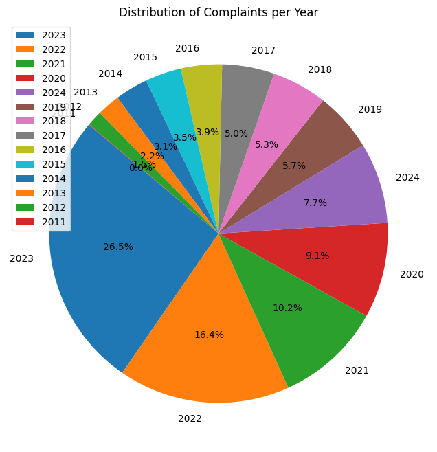

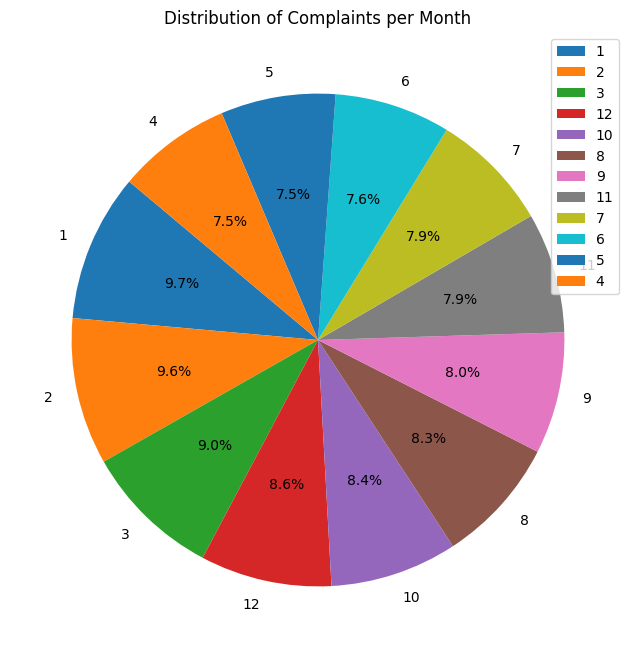

```python
complaints_per_year = df['Date sent to company'].dt.year.value_counts()

plt.figure(figsize=(8, 8))
plt.pie(complaints_per_year, labels=complaints_per_year.index, autopct='%1.1f%%', startangle=140)
plt.title('Distribution of Complaints per Year')
plt.legend()
plt.show()


complaints_per_month = df['Date sent to company'].dt.month.value_counts()

plt.figure(figsize=(8, 8))
plt.pie(complaints_per_month, labels=complaints_per_month.index, autopct='%1.1f%%', startangle=140)
plt.title('Distribution of Complaints per Month')
plt.legend()
plt.show()
```

Here are the distributions of complaints per month and per year. While we observe a predictable increase in complaints over the year, it's notable how evenly complaints are spread across months.I would expect that during spending months this would be up.

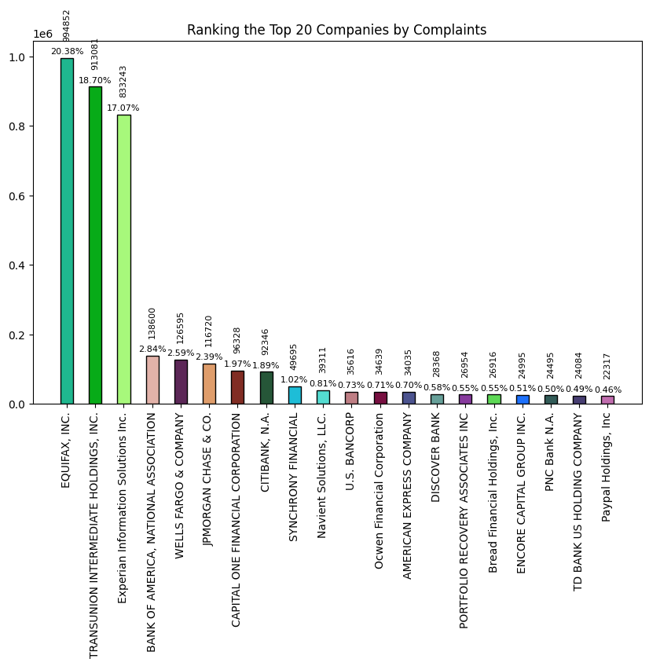

```python
Company_complains_count = df['Company'].value_counts()[:20]

plt.figure(figsize=(10, 6))

plt.title("Ranking the Top 20 Companies by Complaints")
bar_width = 0.8
bar_spacing = 1

bars = plt.bar(np.arange(len(Company_complains_count)) * (bar_width + bar_spacing), Company_complains_count, width=bar_width, edgecolor='black', color=np.random.rand(20,3))
plt.xticks(np.arange(len(Company_complains_count)) * (bar_width + bar_spacing), Company_complains_count.index, rotation=90)

for i, count in enumerate(Company_complains_count):
    plt.text(i * (bar_width + bar_spacing), count + max(Company_complains_count) * 0.05, str(count), ha='center', va='bottom', rotation=90, fontsize=8)
    plt.text(i * (bar_width + bar_spacing), count + max(Company_complains_count) * 0.03, f'{count / len(df) * 100:.2f}%', ha='center', va='top', fontsize=8)

plt.show()
```

Looking at this bar chart, we can see that the majority of companies receiving complaints from consumers are in the financial sector. This data reveals an astounding number, with over 50% of complaints originating from the top 3 companies. I'm not entirely sure if this data is required to be shared or if it truly reflects the quality of the services provided by the company at the top.

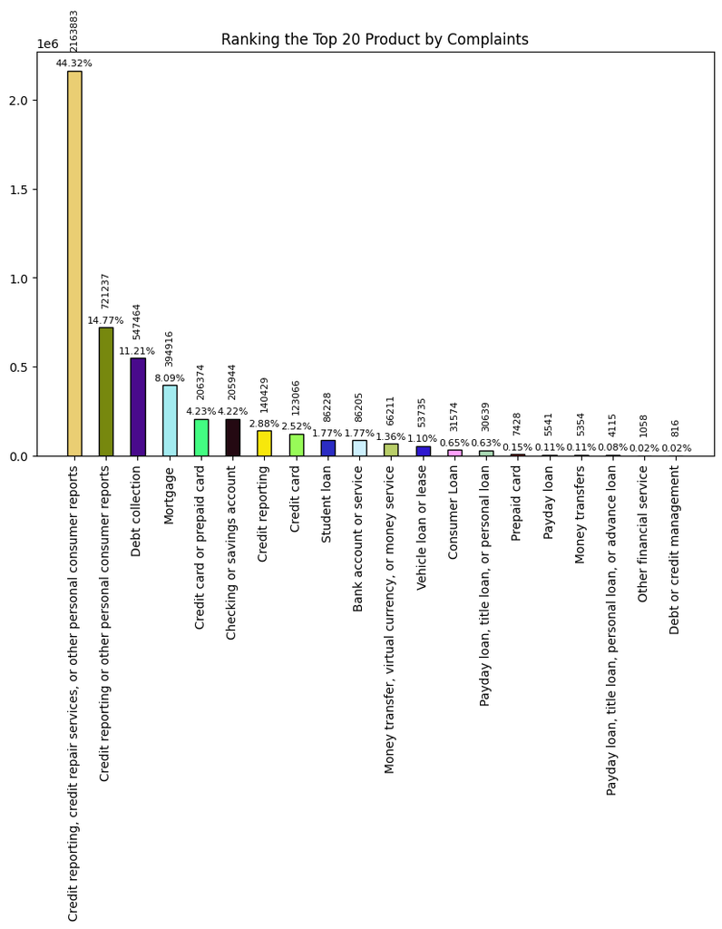

```python
Product_complains_count = df['Product'].value_counts()[:20]

plt.figure(figsize=(10, 6))

plt.title("Ranking the Top 20 Product by Complaints")
bar_width = 0.8
bar_spacing = 1

bars = plt.bar(np.arange(len(Product_complains_count)) * (bar_width + bar_spacing), Product_complains_count, width=bar_width, edgecolor='black', color=np.random.rand(20,3))
plt.xticks(np.arange(len(Product_complains_count)) * (bar_width + bar_spacing), Product_complains_count.index, rotation=90)

for i, count in enumerate(Product_complains_count):
    plt.text(i * (bar_width + bar_spacing), count + max(Product_complains_count) * 0.05, str(count), ha='center', va='bottom', rotation=90, fontsize=8)
    plt.text(i * (bar_width + bar_spacing), count + max(Product_complains_count) * 0.03, f'{count / len(df) * 100:.2f}%', ha='center', va='top', fontsize=8)

plt.show()
```

This aligns pretty well with the what we would expect to see given the companies that have the most complaints.

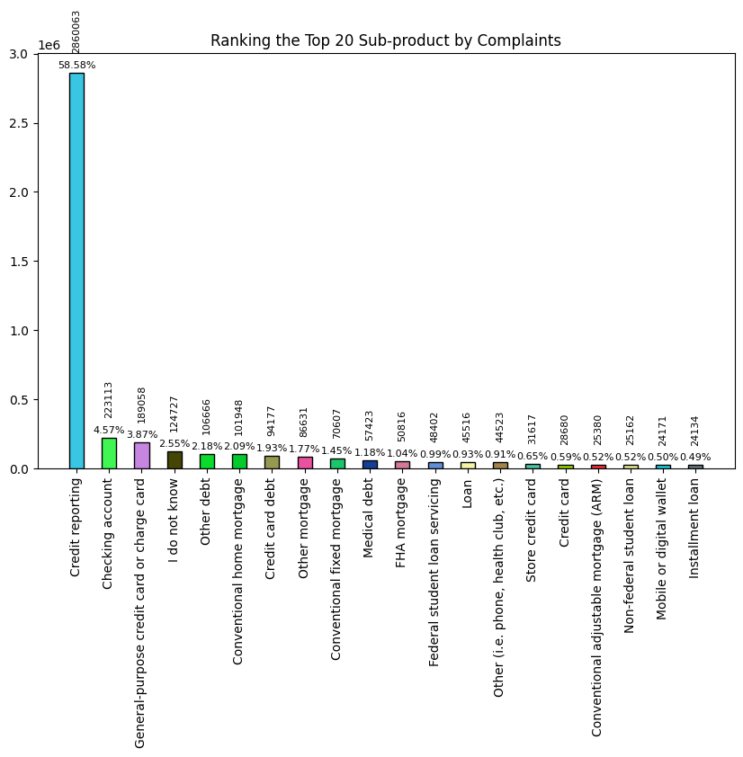

```python
Product_complains_count = df['Sub-product'].value_counts()[:20]

plt.figure(figsize=(10, 6))

plt.title("Ranking the Top 20 Sub-product by Complaints")
bar_width = 0.8
bar_spacing = 1

bars = plt.bar(np.arange(len(Product_complains_count)) * (bar_width + bar_spacing), Product_complains_count, width=bar_width, edgecolor='black', color=np.random.rand(20,3))
plt.xticks(np.arange(len(Product_complains_count)) * (bar_width + bar_spacing), Product_complains_count.index, rotation=90)

for i, count in enumerate(Product_complains_count):
    plt.text(i * (bar_width + bar_spacing), count + max(Product_complains_count) * 0.05, str(count), ha='center', va='bottom', rotation=90, fontsize=8)
    plt.text(i * (bar_width + bar_spacing), count + max(Product_complains_count) * 0.03, f'{count / len(df) * 100:.2f}%', ha='center', va='top', fontsize=8)

plt.show()
```

```python
state_complaints = df['State'].value_counts().reset_index()
state_complaints.columns = ['State', 'Complaints']


fig = px.choropleth(state_complaints,
                    locations='State',
                    locationmode='USA-states',
                    color='Complaints',
                    scope='usa',
                    hover_name='State',
                    title='Complaints by State')
fig.show()
```

[output not shown]

```python
Timely_responses=df['Timely response?'].value_counts()

print(f"Timely respones rate is: {(Timely_responses['Yes']/len(df))*100}%")
```

```
Timely respones rate is: 98.82437039593547%
```

```python
df_2024 = df[df['Date sent to company'].dt.year > 2023]

narratives = df_2024['Consumer complaint narrative'].dropna()
```

```python
narratives_text = ' '.join(narratives)
```

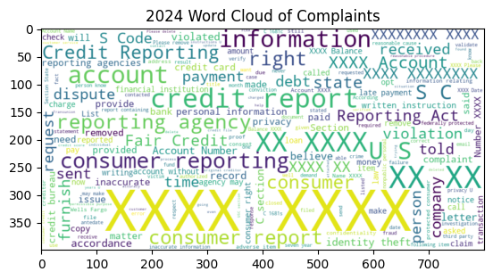

```python
plt.imshow(WordCloud(width=800, height=400, background_color='white').generate(narratives_text)
, interpolation='bilinear')
plt.title('2024 Word Cloud of Complaints')
```

Examining the word cloud of complaints, we can observe the most common words found in complaints in 2024, which largely align with our expectations. The only thing that stands out is the occurrence of words that are just variations on 'XXXX'. While it makes sense why they're there, it wouldn't typically be at the forefront of my mind to include them in this word cloud.

Now I'm going to perform a bit of feature engineering to enhance my ability to gather information from the data. Additionally, I need to optimize the processing given the limitations of my hardware, especially when it comes to analyzing text features about interactions, which are crucial for my task.

, my initial focus will be on creating features base on word count of this interactions

```python
df['Consumer_complaint_narrative_word_count'] = df['Consumer complaint narrative'].apply(lambda x: len(str(x).split()))
df['Company_public_response_word_count'] = df['Company public response'].apply(lambda x: len(str(x).split()))
df['Company_response_to_consumer_word_count'] = df['Company response to consumer'].apply(lambda x: len(str(x).split()))
print(df['Consumer_complaint_narrative_word_count'].describe())
print(df['Company_public_response_word_count'].describe())
print(df['Company_response_to_consumer_word_count'].describe())
```

[output not shown]

From this, we can see that the Consumer_complaint_narrative_word_count, on average, is the longest among the three types of text data examined. This indicates that consumers tend to provide detailed narratives when lodging complaints. Conversely, both the Company_public_response_word_count and the Company_response_to_consumer_word_count have notably lower average word counts, suggesting that companies typically respond with shorter and more concise messages.

The wide standard deviations in all three word count distributions indicate considerable variability in the length of texts. For instance, while the median word count for all three types of texts is relatively low, the maximum word counts reveal instances where narratives or responses are significantly longer, potentially indicating complex issues or detailed explanations.

Let's now create a feature that displays the time passed between the date the complaint was sent to the company and the date it was received.

```python
df['time until response']=df['Date sent to company']-df['Date received']
```

```python
from sklearn.preprocessing import LabelEncoder

categorical_columns = ['Product','State', 'Issue', 'Company', 'Tags','Submitted via','Sub-product','Sub-issue','Consumer consent provided?','Company public response']
label_encoders = {}
for column in categorical_columns:
    label_encoders[column] = LabelEncoder()
    df[column + '_LabelEncoded'] = label_encoders[column].fit_transform(df[column])
```

Now that we've gained insights into the origins and distribution of complaints, our next step is to delve into how various groups respond to these complaints promptly.

However, before proceeding, it's imperative to define what exactly constitutes a "timely response" beyond the mere mention of the term.

How this will be done is by obsevering the Measurement of spread, central tendency, and hypothesis testing of data can help gain a good understanding of how define a time response

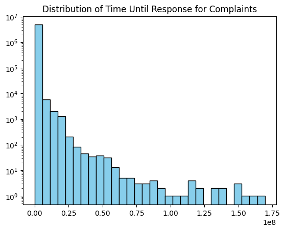

```python
df_yes = df[df['Timely response?'] == 'Yes']
df_no = df[df['Timely response?'] == 'No']

plt.hist(df['time until response'].dt.total_seconds(), bins=30, color='skyblue', edgecolor='black', log=True)
plt.title('Distribution of Time Until Response for Complaints')
plt.show()
```

Here is a distribution of the time until response. We can observe that it is not normally distributed, thereby not satisfying the requirements for using parametric tests. Therefore, we will use the Mann-Whitney U test to determine if there is a significant difference between two groups.

```python
statistic, pvalue = stats.mannwhitneyu(df_yes['time until response'], df_no['time until response'])

print(f'Mann-Whitney U test statistic: {statistic}')
print(f'Mann-Whitney U test p-value: {pvalue}')
```

```
Mann-Whitney U test statistic: 108676668016.0
Mann-Whitney U test p-value: 0.0
```

Based on these results, we can conclude that there is a statistically significant difference in response times between the two groups.Therefore we reject the null that the groups are no difference.

```python
state_averagettr = df.groupby('State')['time until response'].mean()
state_no_count=df_no['State'].value_counts()
state_count=df['State'].value_counts()
state_no_count = df_no['State'].value_counts()

state_count = df['State'].value_counts()

state_no_count_filled = state_no_count.reindex(state_count.index, fill_value=0)

state_no_count_divided = state_no_count_filled / state_count
```

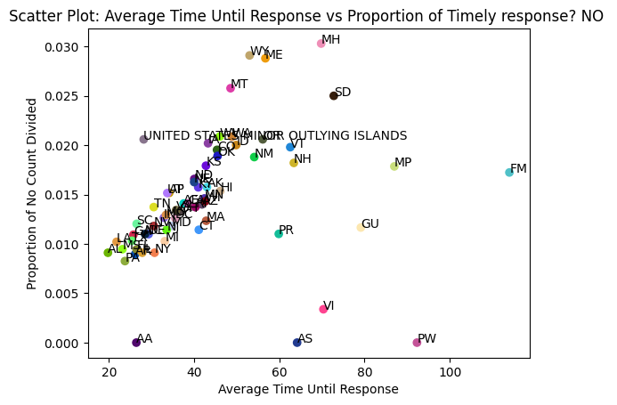

```python
state_averagettr = state_averagettr.dt.total_seconds() / 3600

state_averagettr_sorted = state_averagettr.sort_index()
state_no_count_divided_sorted = state_no_count_divided.sort_index()

plt.scatter(state_averagettr_sorted.values, state_no_count_divided_sorted.values, color=np.random.rand(63, 3))

for i, state in enumerate(state_averagettr_sorted.index):
    plt.annotate(state, (state_averagettr_sorted.values[i], state_no_count_divided_sorted.values[i]))

plt.xlabel('Average Time Until Response')
plt.ylabel('Proportion of No Count Divided')
plt.title('Scatter Plot: Average Time Until Response vs Proportion of Timely response? NO ')

plt.show()
```

For most states, it appears that the average time until response is greater than the proportion of timely responses. However, there are a few outlier states where there are hardly any complaints.

```python
mean_response_time = df['time until response'].mean()
median_response_time = df['time until response'].median()
mode_response_time = df['time until response'].mode()

print("Measurement of central tendency and spread for the entire dataset:")

print(df['time until response'].describe())
print(f"The median of time until response for the entire data is {median_response_time}")
print(f"The mode of time until response for the entire data is {mode_response_time}\n")
```

```
Measurement of central tendency and spread for the entire dataset:
count                      4882235
mean     1 days 07:58:14.621377299
std      8 days 23:43:05.626337110
min              -1 days +00:00:00
25%                0 days 00:00:00
50%                0 days 00:00:00
75%                0 days 00:00:00
max             1962 days 00:00:00
Name: time until response, dtype: object
The median of time until response for the entire data is 0 days 00:00:00
The mode of time until response for the entire data is 0   0 days
Name: time until response, dtype: timedelta64[ns]
```

```python
mean_response_time_yes = df_yes['time until response'].mean()
median_response_time_yes = df_yes['time until response'].median()
mode_response_time_yes = df_yes['time until response'].mode()

print("Measurement of central tendency and spread for customers who reported receiving a timely response:")
print(df_yes['time until response'].describe())
print(f"The median of time until response for customers who reported receiving a timely response is {median_response_time_yes}")
print(f"The mode of time until response for customers who reported receiving a timely response is {mode_response_time_yes}\n")



mean_response_time_no = df_no['time until response'].mean()
median_response_time_no = df_no['time until response'].median()
mode_response_time_no = df_no['time until response'].mode()

print("Measurement of central tendency and spread for customers who reported not receiving a timely response:")
print(df_no['time until response'].describe())
print(f"The median of time until response for customers who reported not receiving a timely response is {median_response_time_yes}")
print(f"The mode of time until response for customers who reported not receiving a timely response is {mode_response_time_yes}")
```

```
Measurement of central tendency and spread for customers who reported receiving a timely response:
count                      4824838
mean     1 days 06:55:42.449217984
std      8 days 18:06:16.103623601
min              -1 days +00:00:00
25%                0 days 00:00:00
50%                0 days 00:00:00
75%                0 days 00:00:00
max             1962 days 00:00:00
Name: time until response, dtype: object
The median of time until response for customers who reported receiving a timely response is 0 days 00:00:00
The mode of time until response for customers who reported receiving a timely response is 0   0 days
Name: time until response, dtype: timedelta64[ns]

Measurement of central tendency and spread for customers who reported not receiving a timely response:
count                         57397
mean      4 days 23:35:05.231980765
std      20 days 09:36:26.433883814
min               -1 days +00:00:00
25%                 0 days 00:00:00
50%                 0 days 00:00:00
75%                 3 days 00:00:00
max              1133 days 00:00:00
Name: time until response, dtype: object
The median of time until response for customers who reported not receiving a timely response is 0 days 00:00:00
The mode of time until response for customers who reported not receiving a timely response is 0   0 days
Name: time until response, dtype: timedelta64[ns]
```

Unsurprisingly, the data pertaining to customers who reported not receiving a timely response exhibits a higher average response time and greater variability in response times compared to those who reported receiving a timely response. This suggests a potential correlation between timely response and improved efficiency in addressing customer inquiries, highlighting the importance of prompt customer service in enhancing overall satisfaction and perception of service quality.

However, this could be due to a small sample size if you remember that 98% of the total dataset falls into the category of customers reporting timely responses. This explains the alignment of measurements in both the category of customers reporting timely responses and the entire dataset. Additionally, we can observe that the maximum values of all the subsets of data are quite high, indicating the presence of outliers in the dataset.

Now let's explore what additional insights we can derive trying to find out about what exactly constitutes a "timely response" beyond the mere mention of the term.Throught looking at how both 'Timely response?' and 'time until response' corrlate with eachother and other variables.

```python
df['Timely response?'] = df['Timely response?'].map({'Yes': 1, 'No': 0})
df['Consumer disputed?'] = df['Consumer disputed?'].map({'Yes': 1, 'No': 0})
```

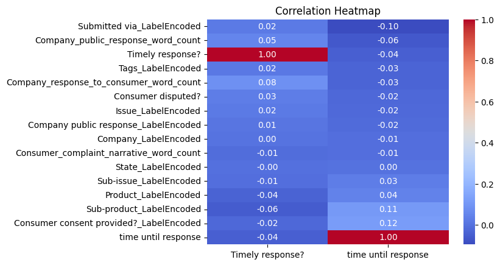

```python
correlation_matrix = df[['Consumer consent provided?_LabelEncoded', 'Timely response?', 'time until response', 'Company public response_LabelEncoded', 'Product_LabelEncoded', 'State_LabelEncoded', 'Issue_LabelEncoded', 'Company_LabelEncoded', 'Tags_LabelEncoded', 'Submitted via_LabelEncoded',
                          'Sub-product_LabelEncoded','Company_response_to_consumer_word_count', 'Sub-issue_LabelEncoded','Company_public_response_word_count', 'Consumer disputed?','Consumer_complaint_narrative_word_count',]].corr()

correlation_values = correlation_matrix[['Timely response?', 'time until response']].sort_values(by='time until response')

sns.heatmap(correlation_values, annot=True, cmap='coolwarm', fmt=".2f")
plt.title('Correlation Heatmap')
plt.show()
```

As we can see, surprisingly, a timely response is only slightly correlated with the time until response. Initially, one might expect a stronger correlation between these factors. This observation gives credence to a substantial contingent of people who reported a non-timely response, even though it was resolved within the same day, compared to the large number of people who did report timely service.

However finding like the Mann-Whitney U test suggests that there is a significant difference in 'time until response' between the two groups of customers.

Which is why we now we should take a look at another two non parametric test like the spearman correlation and Kendall's Tau to help confirme the hypothisis of correlation between the two.

```python
res_sp = stats.spearmanr(df['Timely response?'], df['time until response'])
print('Spearman correlation coefficient:', res_sp.correlation)
print('p-value:', res_sp.pvalue)
```

```
Spearman correlation coefficient: -0.06542251718771507
p-value: 0.0
```

suggests a weak negative monotonic relationship between 'time until response' and 'Timely response?'. Despite being statistically significant, the magnitude of the coefficient indicates that the association between the variables is relatively small.

```python
res_kt = stats.kendalltau(df['Timely response?'], df['time until response'])
print('kendall tau correlation coefficient:', res_kt.correlation)
print('p-value:', res_kt.pvalue)
```

```
kendall tau correlation coefficient: -0.06331432001644106
p-value: 0.0
```

Similarly, the Kendall Tau correlation coefficient measures the strength and direction of association between variables based on concordant and discordant pairs of observations. Kendall's Tau also suggests a weak negative association between 'time until response' and 'Timely response?'. Like the Spearman coefficient, the Kendall Tau coefficient is statistically significant but indicates a modest relationship between the variables.

```python
print('Spearman correlation coefficient:', res_sp.correlation)
print('kendall tau correlation coefficient:', res_kt.correlation)
print('Correlation coefficient:', correlation_values['time until response']['Timely response?'])
```

```
Spearman correlation coefficient: -0.06542251718771507
kendall tau correlation coefficient: -0.06331432001644106
Correlation coefficient: -0.04429862277436288
```

In summary, all three correlation coefficients indicate a consistent pattern of a weak negative correlation between 'time until response' and 'Timely response?'. Although statistically significant, the strength of this association is relatively small, suggesting that other factors not considered in the analysis have a greater influence the timely response.

With that I now want to go back and examine the people who reported not receiving a timely response that received the same level of service in terms of time taken compared to those who reported receiving a timely response.

```python
df_no_positive_response_time = df_no[df_no['time until response'].dt.days < 1]

proportion = len(df_no_positive_response_time) / len(df_no)
print("Proportion of cases where time until response is less than 1 day out of the subgroup:", proportion)
```

```
Proportion of cases where time until response is less than 1 day out of the subgroup: 0.6516020001045351
```

```python
no_positive_response_counts = df_no_positive_response_time['Company'].value_counts()
total_counts_filtered = df['Company'].value_counts()

total_counts_filtered = total_counts_filtered[total_counts_filtered.index.isin(no_positive_response_counts.index)]

total_counts_filtered = total_counts_filtered.reindex(no_positive_response_counts.index, fill_value=0)

ratio = no_positive_response_counts / total_counts_filtered

countsdf = pd.DataFrame({'Company': total_counts_filtered.index,
                         'complaint_count': total_counts_filtered.values,
                         'fast_complaint_count':no_positive_response_counts.values,
                         'ratio': ratio.values})

countsdf['rank'] = countsdf['complaint_count'].rank(pct=True)


countsdf
```

|  | Company | complaint_count | fast_complaint_count | ratio | rank |
| --- | --- | --- | --- | --- | --- |
| 0 | WELLS FARGO & COMPANY | 126595 | 2436 | 0.019242 | 0.998737 |
| 1 | BANK OF AMERICA, NATIONAL ASSOCIATION | 138600 | 2333 | 0.016833 | 0.999053 |
| 2 | EQUIFAX, INC. | 994852 | 1663 | 0.001672 | 1.000000 |
| 3 | EdFinancial Services | 3309 | 1022 | 0.308855 | 0.970319 |
| 4 | Mobiloans, LLC | 581 | 421 | 0.724613 | 0.898326 |
| ... | ... | ... | ... | ... | ... |
| 3162 | American Liberty Mortgage, Inc. | 5 | 1 | 0.200000 | 0.168772 |
| 3163 | West One Capital Group Inc. | 3 | 1 | 0.333333 | 0.094411 |
| 3164 | St.John Cobb Inc | 14 | 1 | 0.071429 | 0.355226 |
| 3165 | Asset Acquisition Group, LLC | 6 | 1 | 0.166667 | 0.198926 |
| 3166 | MDE Home Loans, LLC | 7 | 1 | 0.142857 | 0.227187 |

3167 rows × 5 columns

```python
print(ratio.describe())
countsdf = countsdf[countsdf['ratio'] > 0.70]

countsdf['rank'].describe()
```

```
count    3167.000000
mean        0.228792
std         0.250186
min         0.000051
25%         0.034965
50%         0.125000
75%         0.333333
max         1.000000
Name: count, dtype: float64
```

```
count    194.000000
mean       0.197170
std        0.201745
min        0.008052
25%        0.008052
50%        0.134512
75%        0.311138
max        0.898326
Name: rank, dtype: float64
```

Moreover, when examining the descriptive statistics regarding the rank size of companies with a 'ratio' > 0.70. a pattern emerges most companies with a specific response type generally have a modest overall presence. This observation aligns logically, as a single complaint of this nature can yield a ratio of 1. However, there are a select few companies within the upper echelons that meet this criteria.

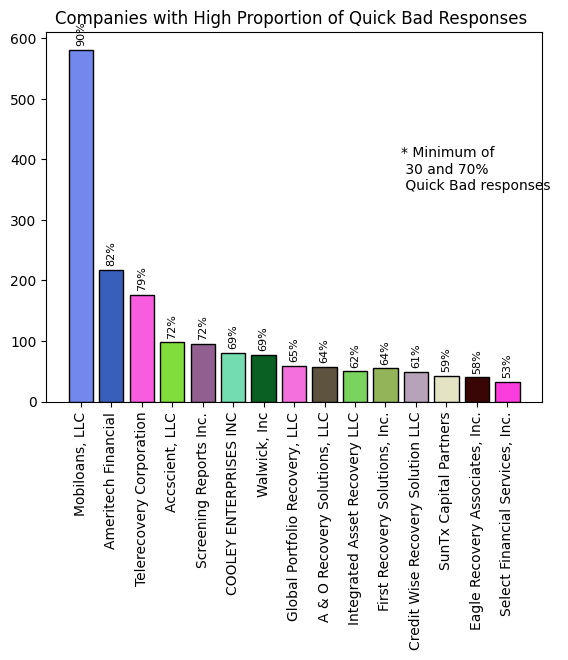

```python
plt.bar(countsdf["Company"][:15], countsdf['complaint_count'][:15], edgecolor='black', color=np.random.rand(15, 3))
plt.title('Companies with High Proportion of Quick Bad Responses ')
plt.xticks(rotation=90)
plt.text(10.5, 350, '* Minimum of\n 30 and 70% \n Quick Bad responses  ', fontsize=10, color='black')

for i, rank in enumerate(countsdf['rank'][:15]):
    plt.text(i, countsdf['complaint_count'].iloc[i] + 10, f"{rank:.0%}", ha='center',fontsize=8, rotation=90 )

plt.show()
```

Here is a visltion of that obsevertion as we can see these Companies with High Proportion of Quick Bad Responses

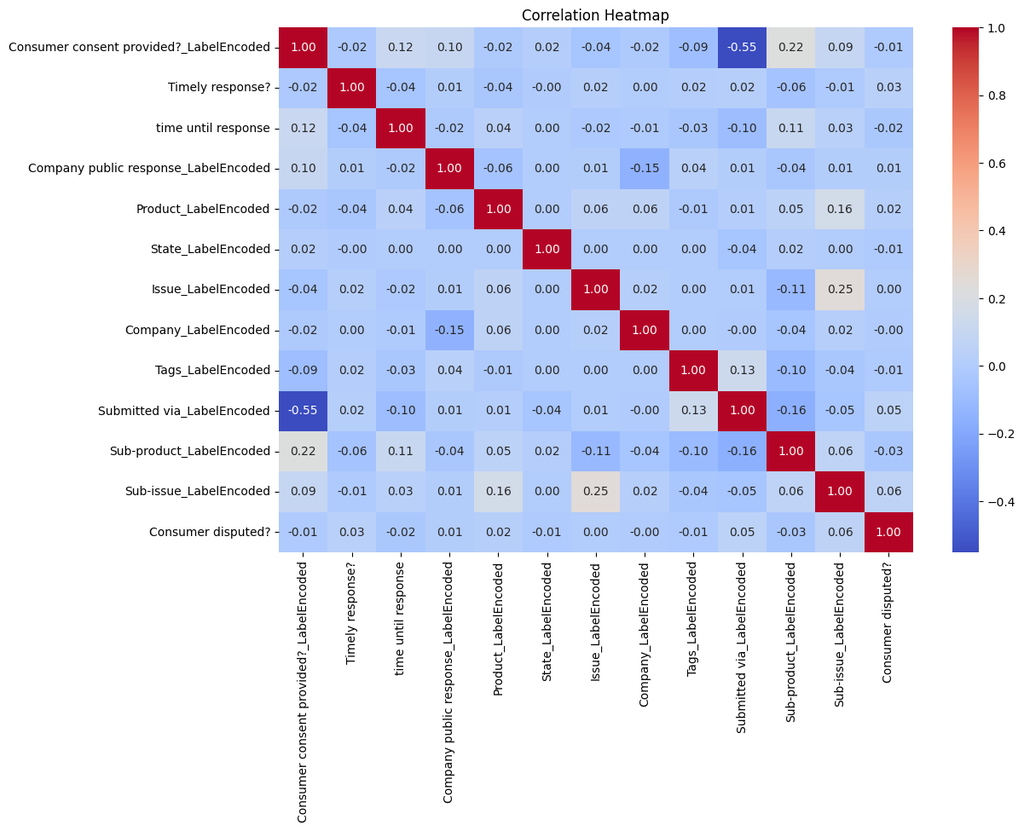

```python
correlation_matrix = df[['Consumer consent provided?_LabelEncoded', 'Timely response?', 'time until response', 'Company public response_LabelEncoded', 'Product_LabelEncoded', 'State_LabelEncoded', 'Issue_LabelEncoded', 'Company_LabelEncoded', 'Tags_LabelEncoded', 'Submitted via_LabelEncoded', 'Sub-product_LabelEncoded', 'Sub-issue_LabelEncoded', 'Consumer disputed?']].corr()

correlation_values = correlation_matrix

plt.figure(figsize=(12, 8))
sns.heatmap(correlation_values, annot=True, cmap='coolwarm', fmt=".2f")
plt.title('Correlation Heatmap')
plt.show()
```

The final stage of this analysis aims to develop predictive models to ascertain whether a response was timely. Our initial approach will involve using a Logistic Regression model. Starting with a simple model like Logistic Regression is a prudent choice as it allows us to establish a baseline performance. If the initial model proves effective, we may proceed with it. However, if further refinement is necessary, we can explore more complex models later in the analysis.

```python
LRnmodel = LogisticRegression(class_weight='balanced')
df_model= df.select_dtypes(exclude=object)

Y = df_model['Timely response?']


X=df_model[[
    'Complaint ID',
       'Consumer_complaint_narrative_word_count',
       'Company_public_response_word_count',
       'Company_response_to_consumer_word_count', 'time until response',
       'Product_LabelEncoded', 'State_LabelEncoded', 'Issue_LabelEncoded',
       'Company_LabelEncoded', 'Tags_LabelEncoded',
       'Submitted via_LabelEncoded', 'Sub-product_LabelEncoded',
       'Sub-issue_LabelEncoded', 'Consumer consent provided?_LabelEncoded',
       'Company public response_LabelEncoded']]
X.loc[:, 'time until response'] = X['time until response'].dt.days.astype(int)

X_train, X_test, y_train, y_test = train_test_split(X,Y,train_size=.7)
LRnmodel.fit(X_train,y_train)
```

```
LogisticRegression(class_weight='balanced')
```

Now the model it created we want to test its performance

```python
# Make predictions on the test set
y_pred = LRnmodel.predict(X_test)


def prediction_scores(y_pred, y_test):
    accuracy = accuracy_score(y_test, y_pred)
    precision = precision_score(y_test, y_pred)
    recall = recall_score(y_test, y_pred)
    f1 = f1_score(y_test, y_pred)
    roc_auc = roc_auc_score(y_test, y_pred)
    f2 = fbeta_score(y_test, y_pred, beta=2)
    cm = confusion_matrix(y_test, y_pred)
    tn, fp, fn, tp = cm.ravel()
    specificity_score = tn / (tn + fp)

    print("Accuracy:", accuracy)
    print("Precision:", precision)
    print("Recall:", recall)
    print("F1 Score:", f1)
    print("ROC-AUC Score:", roc_auc)
    print("F2 Score:", f2)
    print("Specificity:", specificity_score)

    specificity_score = tn / (tn + fp)

    return accuracy, precision, recall, f1, roc_auc, f2,specificity_score

prediction_scores(y_test, y_pred)
# talk about the cost of Precision vs Accuracy
```

```
Accuracy: 0.7531193011946028
Precision: 0.7565451591974247
Recall: 0.9916237241779041
F1 Score: 0.8582787800497045
ROC-AUC Score: 0.5070898490008836
F2 Score: 0.9336046020063603
Specificity: 0.022555973823863117
```

```
(0.7531193011946028,
 0.7565451591974247,
 0.9916237241779041,
 0.8582787800497045,
 0.5070898490008836,
 0.9336046020063603,
 0.022555973823863117)
```

```python
skf = StratifiedKFold(n_splits=7, shuffle=True)
skf_score = cross_val_score(LRnmodel,X,Y,cv=skf)
```

```python
precision, recall, thresholds = precision_recall_curve(y_test, y_pred)

auc_prc = auc(recall, precision)

print(auc_prc)
```

```
0.9943674267402802
```

```python
print(f"skf_score mean:{skf_score.mean()}")
print(f"skf_score Std :{skf_score.std()}")
```

```
skf_score mean:0.7528572466524288
skf_score Std :0.0009487031330054858
```

The results of the cross-validation seem to align with the findings that the model is not performing well.We also see a low variance.

Now that we've assessed the performance of logistic regression, I'll proceed to employ a more sophisticated model, namely gradient boosting, to evaluate if it enhances the metrics above.

```python
def run_bst(n, depth, a):
    bstmodel = xgb.XGBClassifier(n_estimators=n, max_depth=depth, learning_rate=a, objective='binary:logistic')
    bstmodel.fit(X_train, y_train)
    bsty_pred = bstmodel.predict(X_test)
    prediction_scores(y_test, bsty_pred)

n_estimators_list = [6, 8, 10]
max_depth_list = [4, 5, 6]
learning_rate_list = [.1,.5]

for n in n_estimators_list:
    for depth in max_depth_list:
        for a in learning_rate_list:
            print(f"n estimators: {n}, max depth: {depth}, learning rate: {a}")
            run_bst(n, depth, a)
            print("\n")
```

```
n estimators: 6, max depth: 4, learning rate: 0.1
Accuracy: 0.9894372183241151
Precision: 0.9999944724315981
Recall: 0.9894287866793005
F1 Score: 0.9946835727518242
ROC-AUC Score: 0.9926364712617282
F2 Score: 0.9915240245126417
Specificity: 0.9958441558441559


n estimators: 6, max depth: 4, learning rate: 0.5
Accuracy: 0.9901745852822921
Precision: 0.9999889448631961
Recall: 0.9901652242328874
F1 Score: 0.9950528388166002
ROC-AUC Score: 0.9924344823580856
F2 Score: 0.9921144969125534
Specificity: 0.9947037404832837


n estimators: 6, max depth: 5, learning rate: 0.1
Accuracy: 0.9898509631173144
Precision: 0.9999972362157991
Recall: 0.9898361862137075
F1 Score: 0.9948907676015892
ROC-AUC Score: 0.9941253860121252
F2 Score: 0.9918518430188641
Specificity: 0.998414585810543


n estimators: 6, max depth: 5, learning rate: 0.5
Accuracy: 0.9901226964963463
Precision: 0.999959925129086
Recall: 0.9901419088942436
F1 Score: 0.9950266987929939
ROC-AUC Score: 0.9854968375768676
F2 Score: 0.9920900582256935
Specificity: 0.9808517662594916


```

[output cut: 123 more lines]

```
Recall: 0.989961380453831
F1 Score: 0.9949509236932607
ROC-AUC Score: 0.9925883457293079
F2 Score: 0.9919511804281966
Specificity: 0.9952153110047847


n estimators: 10, max depth: 6, learning rate: 0.5
Accuracy: 0.9902640251633302
Precision: 0.9997319129325063
Recall: 0.99050367099656
F1 Score: 0.9950963973995088
ROC-AUC Score: 0.9454571743073149
F2 Score: 0.9923356648498004
Specificity: 0.9004106776180698
```

We evaluated a binary classification model using different combinations of hyperparameters (number of estimators, maximum depth, learning rate) with XGBoost.

Optimal Configuration:

The combination of n estimators: 10, max depth: 4, learning rate: 0.5 stood out:

Accuracy, precision, recall,Specificity, F1 and F2 score were all close to 1.0. ROC-AUC score and Specificity was notably high and show a great increase for logistic regression, indicating strong class discrimination.